# Project: Wrangle and Analyze Data - Wrangle

## Setup

```python
import tweepy
from tweepy import OAuthHandler
import json
from timeit import default_timer as timer
import pandas as pd
import requests
from configparser import ConfigParser

config = ConfigParser()
config.read('twitter.ini')
consumer_key = config.get("twitter", "consumer_key")
consumer_secret = config.get("twitter", "consumer_secret")
access_token = config.get("twitter", "access_token")
access_secret = config.get("twitter", "access_secret")
```

## Gather

### twitter archive enhanced

```python
df_twitter = pd.read_csv("twitter-archive-enhanced.csv")
df_twitter.head()
```

|  | tweet_id | in_reply_to_status_id | in_reply_to_user_id | timestamp | source | text | retweeted_status_id | retweeted_status_user_id | retweeted_status_timestamp | expanded_urls | rating_numerator | rating_denominator | name | doggo | floofer | pupper | puppo |
| --- | --- | --- | --- | --- | --- | --- | --- | --- | --- | --- | --- | --- | --- | --- | --- | --- | --- |
| 0 | 892420643555336193 | NaN | NaN | 2017-08-01 16:23:56 +0000 | <a href="http://twitter.com/download/iphone" r... | This is Phineas. He's a mystical boy. Only eve... | NaN | NaN | NaN | https://twitter.com/dog_rates/status/892420643... | 13 | 10 | Phineas | None | None | None | None |
| 1 | 892177421306343426 | NaN | NaN | 2017-08-01 00:17:27 +0000 | <a href="http://twitter.com/download/iphone" r... | This is Tilly. She's just checking pup on you.... | NaN | NaN | NaN | https://twitter.com/dog_rates/status/892177421... | 13 | 10 | Tilly | None | None | None | None |
| 2 | 891815181378084864 | NaN | NaN | 2017-07-31 00:18:03 +0000 | <a href="http://twitter.com/download/iphone" r... | This is Archie. He is a rare Norwegian Pouncin... | NaN | NaN | NaN | https://twitter.com/dog_rates/status/891815181... | 12 | 10 | Archie | None | None | None | None |
| 3 | 891689557279858688 | NaN | NaN | 2017-07-30 15:58:51 +0000 | <a href="http://twitter.com/download/iphone" r... | This is Darla. She commenced a snooze mid meal... | NaN | NaN | NaN | https://twitter.com/dog_rates/status/891689557... | 13 | 10 | Darla | None | None | None | None |
| 4 | 891327558926688256 | NaN | NaN | 2017-07-29 16:00:24 +0000 | <a href="http://twitter.com/download/iphone" r... | This is Franklin. He would like you to stop ca... | NaN | NaN | NaN | https://twitter.com/dog_rates/status/891327558... | 12 | 10 | Franklin | None | None | None | None |

### tweet image predictions

```python
prediction_file = "image-predictions.tsv"
prediction_url = f"https://d17h27t6h515a5.cloudfront.net/topher/2017/August/599fd2ad_image-predictions/{prediction_file}"

with open(prediction_file, 'wb') as file:
    try:
        prediction_request = requests.get(prediction_url)
        file.write(prediction_request.content)
    except Exception as e:
        print(f"failed to get {prediction_file}: {e}")

df_prediction = pd.read_csv(prediction_file, sep="\t")
df_prediction.head()
```

|  | tweet_id | jpg_url | img_num | p1 | p1_conf | p1_dog | p2 | p2_conf | p2_dog | p3 | p3_conf | p3_dog |
| --- | --- | --- | --- | --- | --- | --- | --- | --- | --- | --- | --- | --- |
| 0 | 666020888022790149 | https://pbs.twimg.com/media/CT4udn0WwAA0aMy.jpg | 1 | Welsh_springer_spaniel | 0.465074 | True | collie | 0.156665 | True | Shetland_sheepdog | 0.061428 | True |
| 1 | 666029285002620928 | https://pbs.twimg.com/media/CT42GRgUYAA5iDo.jpg | 1 | redbone | 0.506826 | True | miniature_pinscher | 0.074192 | True | Rhodesian_ridgeback | 0.072010 | True |
| 2 | 666033412701032449 | https://pbs.twimg.com/media/CT4521TWwAEvMyu.jpg | 1 | German_shepherd | 0.596461 | True | malinois | 0.138584 | True | bloodhound | 0.116197 | True |
| 3 | 666044226329800704 | https://pbs.twimg.com/media/CT5Dr8HUEAA-lEu.jpg | 1 | Rhodesian_ridgeback | 0.408143 | True | redbone | 0.360687 | True | miniature_pinscher | 0.222752 | True |
| 4 | 666049248165822465 | https://pbs.twimg.com/media/CT5IQmsXIAAKY4A.jpg | 1 | miniature_pinscher | 0.560311 | True | Rottweiler | 0.243682 | True | Doberman | 0.154629 | True |

### tweet data

#### Accessing API

```python
tweet_ids = df_twitter.tweet_id.values
auth_handler = OAuthHandler(consumer_key, consumer_secret)
auth_handler.set_access_token(access_token, access_secret)
api = tweepy.API(auth_handler, wait_on_rate_limit=True)

count = 0
fails_dict = {}
start = timer()
# Save each tweet's returned JSON as a new line in a .txt file
with open('tweet_json.txt', 'w') as outfile:
    # This loop will likely take 20-30 minutes to run because of Twitter's rate limit
    for tweet_id in tweet_ids:
        count += 1
        print(str(count) + ": " + str(tweet_id))
        try:
            tweet = api.get_status(tweet_id, tweet_mode='extended')
            print("Success")
            json.dump(tweet._json, outfile)
            outfile.write('\n')
        except tweepy.TweepError as e:
            print(f"Fail: {e}")
            fails_dict[tweet_id] = e
            pass
end = timer()
print(end - start)
print(fails_dict)
```

[output not shown]

[output cut: 4659 more lines]

[output not shown]

#### Loading into DataFrame

```python
df_twitter_detail = pd.read_json("tweet_json.txt", lines=True)
df_twitter_detail.head()
```

|  | created_at | id | id_str | full_text | truncated | display_text_range | entities | extended_entities | source | in_reply_to_status_id | ... | favorited | retweeted | possibly_sensitive | possibly_sensitive_appealable | lang | retweeted_status | quoted_status_id | quoted_status_id_str | quoted_status_permalink | quoted_status |
| --- | --- | --- | --- | --- | --- | --- | --- | --- | --- | --- | --- | --- | --- | --- | --- | --- | --- | --- | --- | --- | --- |
| 0 | 2017-08-01 16:23:56+00:00 | 892420643555336193 | 892420643555336192 | This is Phineas. He's a mystical boy. Only eve... | False | [0, 85] | {'hashtags': [], 'symbols': [], 'user_mentions... | {'media': [{'id': 892420639486877696, 'id_str'... | <a href="http://twitter.com/download/iphone" r... | NaN | ... | False | False | 0.0 | 0.0 | en | NaN | NaN | NaN | NaN | NaN |
| 1 | 2017-08-01 00:17:27+00:00 | 892177421306343426 | 892177421306343424 | This is Tilly. She's just checking pup on you.... | False | [0, 138] | {'hashtags': [], 'symbols': [], 'user_mentions... | {'media': [{'id': 892177413194625024, 'id_str'... | <a href="http://twitter.com/download/iphone" r... | NaN | ... | False | False | 0.0 | 0.0 | en | NaN | NaN | NaN | NaN | NaN |
| 2 | 2017-07-31 00:18:03+00:00 | 891815181378084864 | 891815181378084864 | This is Archie. He is a rare Norwegian Pouncin... | False | [0, 121] | {'hashtags': [], 'symbols': [], 'user_mentions... | {'media': [{'id': 891815175371796480, 'id_str'... | <a href="http://twitter.com/download/iphone" r... | NaN | ... | False | False | 0.0 | 0.0 | en | NaN | NaN | NaN | NaN | NaN |
| 3 | 2017-07-30 15:58:51+00:00 | 891689557279858688 | 891689557279858688 | This is Darla. She commenced a snooze mid meal... | False | [0, 79] | {'hashtags': [], 'symbols': [], 'user_mentions... | {'media': [{'id': 891689552724799489, 'id_str'... | <a href="http://twitter.com/download/iphone" r... | NaN | ... | False | False | 0.0 | 0.0 | en | NaN | NaN | NaN | NaN | NaN |
| 4 | 2017-07-29 16:00:24+00:00 | 891327558926688256 | 891327558926688256 | This is Franklin. He would like you to stop ca... | False | [0, 138] | {'hashtags': [{'text': 'BarkWeek', 'indices': ... | {'media': [{'id': 891327551943041024, 'id_str'... | <a href="http://twitter.com/download/iphone" r... | NaN | ... | False | False | 0.0 | 0.0 | en | NaN | NaN | NaN | NaN | NaN |

5 rows × 32 columns

## Assess

### twitter archive enhanced

#### describe

```python
df_twitter.describe()
```

|  | tweet_id | in_reply_to_status_id | in_reply_to_user_id | retweeted_status_id | retweeted_status_user_id | rating_numerator | rating_denominator |
| --- | --- | --- | --- | --- | --- | --- | --- |
| count | 2.356000e+03 | 7.800000e+01 | 7.800000e+01 | 1.810000e+02 | 1.810000e+02 | 2356.000000 | 2356.000000 |
| mean | 7.427716e+17 | 7.455079e+17 | 2.014171e+16 | 7.720400e+17 | 1.241698e+16 | 13.126486 | 10.455433 |
| std | 6.856705e+16 | 7.582492e+16 | 1.252797e+17 | 6.236928e+16 | 9.599254e+16 | 45.876648 | 6.745237 |
| min | 6.660209e+17 | 6.658147e+17 | 1.185634e+07 | 6.661041e+17 | 7.832140e+05 | 0.000000 | 0.000000 |
| 25% | 6.783989e+17 | 6.757419e+17 | 3.086374e+08 | 7.186315e+17 | 4.196984e+09 | 10.000000 | 10.000000 |
| 50% | 7.196279e+17 | 7.038708e+17 | 4.196984e+09 | 7.804657e+17 | 4.196984e+09 | 11.000000 | 10.000000 |
| 75% | 7.993373e+17 | 8.257804e+17 | 4.196984e+09 | 8.203146e+17 | 4.196984e+09 | 12.000000 | 10.000000 |
| max | 8.924206e+17 | 8.862664e+17 | 8.405479e+17 | 8.874740e+17 | 7.874618e+17 | 1776.000000 | 170.000000 |

#### info

```python
df_twitter.info()
```

```
<class 'pandas.core.frame.DataFrame'>
RangeIndex: 2356 entries, 0 to 2355
Data columns (total 17 columns):
 #   Column                      Non-Null Count  Dtype
---  ------                      --------------  -----
 0   tweet_id                    2356 non-null   int64
 1   in_reply_to_status_id       78 non-null     float64
 2   in_reply_to_user_id         78 non-null     float64
 3   timestamp                   2356 non-null   object
 4   source                      2356 non-null   object
 5   text                        2356 non-null   object
 6   retweeted_status_id         181 non-null    float64
 7   retweeted_status_user_id    181 non-null    float64
 8   retweeted_status_timestamp  181 non-null    object
 9   expanded_urls               2297 non-null   object
 10  rating_numerator            2356 non-null   int64
 11  rating_denominator          2356 non-null   int64
 12  name                        2356 non-null   object
 13  doggo                       2356 non-null   object
 14  floofer                     2356 non-null   object
 15  pupper                      2356 non-null   object
 16  puppo                       2356 non-null   object
dtypes: float64(4), int64(3), object(10)
memory usage: 313.0+ KB
```

#### Expanded Url values are incorrect

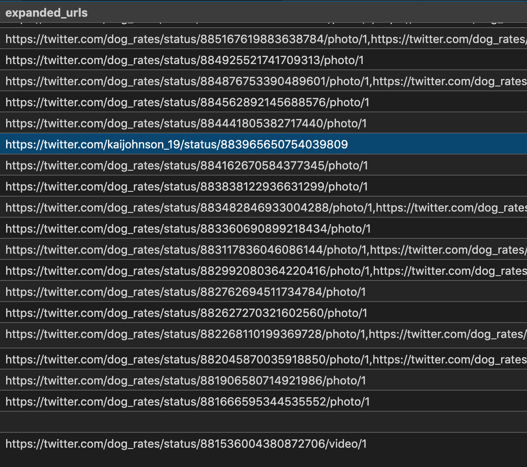

#### Invalid Names

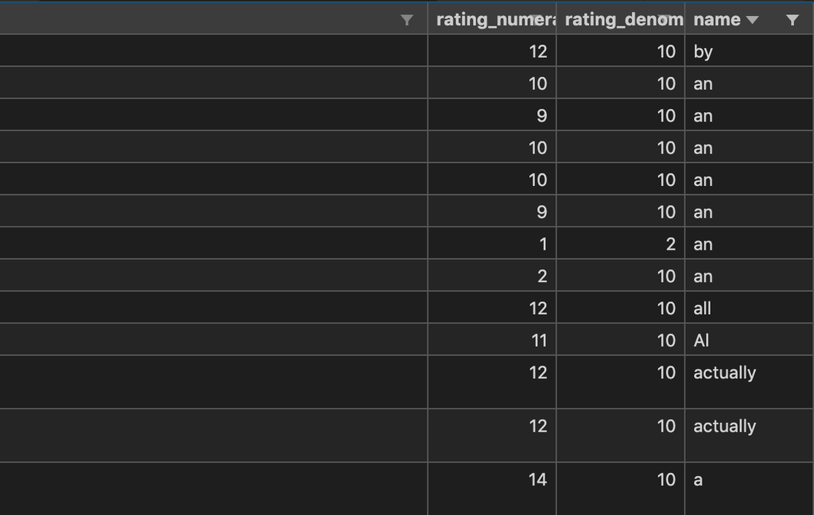

```python
df_twitter[(df_twitter.name.str.len() < 4) & (df_twitter.name.isnull() == False)].name.value_counts()
```

```
a      55
Bo      9
the     8
an      7
Leo     6
       ..
Jeb     1
Pip     1
Amy     1
Aja     1
Jim     1
Name: name, Length: 68, dtype: int64
```

#### Incorrect name

```python
df_twitter.query("name == 'Al'")[["name", "text"]]
```

|  | name | text |
| --- | --- | --- |
| 820 | Al | Meet Al Cabone. He's a gangsta puppa. Rather h... |

#### Expanded Url contains more than 1 values

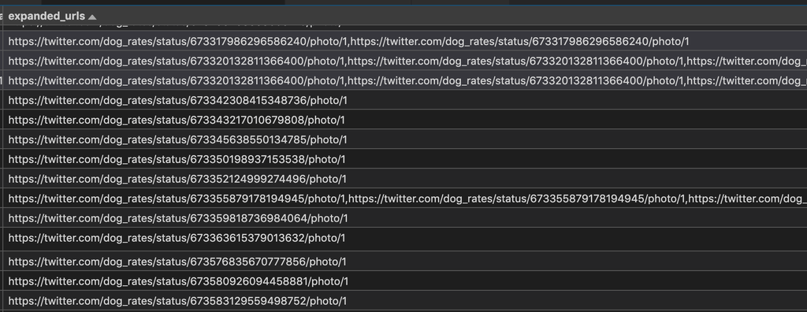

#### stages duplication

##### doggo + floofer

```python
df_twitter.query("(doggo != 'None') & (floofer != 'None')")
```

|  | tweet_id | in_reply_to_status_id | in_reply_to_user_id | timestamp | source | text | retweeted_status_id | retweeted_status_user_id | retweeted_status_timestamp | expanded_urls | rating_numerator | rating_denominator | name | doggo | floofer | pupper | puppo |
| --- | --- | --- | --- | --- | --- | --- | --- | --- | --- | --- | --- | --- | --- | --- | --- | --- | --- |
| 200 | 854010172552949760 | NaN | NaN | 2017-04-17 16:34:26 +0000 | <a href="http://twitter.com/download/iphone" r... | At first I thought this was a shy doggo, but i... | NaN | NaN | NaN | https://twitter.com/dog_rates/status/854010172... | 11 | 10 | None | doggo | floofer | None | None |

##### doggo + puppo

```python
df_twitter.query("(doggo != 'None') & (puppo != 'None')")
```

|  | tweet_id | in_reply_to_status_id | in_reply_to_user_id | timestamp | source | text | retweeted_status_id | retweeted_status_user_id | retweeted_status_timestamp | expanded_urls | rating_numerator | rating_denominator | name | doggo | floofer | pupper | puppo |
| --- | --- | --- | --- | --- | --- | --- | --- | --- | --- | --- | --- | --- | --- | --- | --- | --- | --- |
| 191 | 855851453814013952 | NaN | NaN | 2017-04-22 18:31:02 +0000 | <a href="http://twitter.com/download/iphone" r... | Here's a puppo participating in the #ScienceMa... | NaN | NaN | NaN | https://twitter.com/dog_rates/status/855851453... | 13 | 10 | None | doggo | None | None | puppo |

##### doggo + pupper

```python
df_twitter.query("(doggo != 'None') & (pupper != 'None')")
```

|  | tweet_id | in_reply_to_status_id | in_reply_to_user_id | timestamp | source | text | retweeted_status_id | retweeted_status_user_id | retweeted_status_timestamp | expanded_urls | rating_numerator | rating_denominator | name | doggo | floofer | pupper | puppo |
| --- | --- | --- | --- | --- | --- | --- | --- | --- | --- | --- | --- | --- | --- | --- | --- | --- | --- |
| 460 | 817777686764523521 | NaN | NaN | 2017-01-07 16:59:28 +0000 | <a href="http://twitter.com/download/iphone" r... | This is Dido. She's playing the lead role in "... | NaN | NaN | NaN | https://twitter.com/dog_rates/status/817777686... | 13 | 10 | Dido | doggo | None | pupper | None |
| 531 | 808106460588765185 | NaN | NaN | 2016-12-12 00:29:28 +0000 | <a href="http://twitter.com/download/iphone" r... | Here we have Burke (pupper) and Dexter (doggo)... | NaN | NaN | NaN | https://twitter.com/dog_rates/status/808106460... | 12 | 10 | None | doggo | None | pupper | None |
| 565 | 802265048156610565 | 7.331095e+17 | 4.196984e+09 | 2016-11-25 21:37:47 +0000 | <a href="http://twitter.com/download/iphone" r... | Like doggo, like pupper version 2. Both 11/10 ... | NaN | NaN | NaN | https://twitter.com/dog_rates/status/802265048... | 11 | 10 | None | doggo | None | pupper | None |
| 575 | 801115127852503040 | NaN | NaN | 2016-11-22 17:28:25 +0000 | <a href="http://twitter.com/download/iphone" r... | This is Bones. He's being haunted by another d... | NaN | NaN | NaN | https://twitter.com/dog_rates/status/801115127... | 12 | 10 | Bones | doggo | None | pupper | None |
| 705 | 785639753186217984 | NaN | NaN | 2016-10-11 00:34:48 +0000 | <a href="http://twitter.com/download/iphone" r... | This is Pinot. He's a sophisticated doggo. You... | NaN | NaN | NaN | https://twitter.com/dog_rates/status/785639753... | 10 | 10 | Pinot | doggo | None | pupper | None |
| 733 | 781308096455073793 | NaN | NaN | 2016-09-29 01:42:20 +0000 | <a href="http://vine.co" rel="nofollow">Vine -... | Pupper butt 1, Doggo 0. Both 12/10 https://t.c... | NaN | NaN | NaN | https://vine.co/v/5rgu2Law2ut | 12 | 10 | None | doggo | None | pupper | None |
| 778 | 775898661951791106 | NaN | NaN | 2016-09-14 03:27:11 +0000 | <a href="http://twitter.com/download/iphone" r... | RT @dog_rates: Like father (doggo), like son (... | 7.331095e+17 | 4.196984e+09 | 2016-05-19 01:38:16 +0000 | https://twitter.com/dog_rates/status/733109485... | 12 | 10 | None | doggo | None | pupper | None |
| 822 | 770093767776997377 | NaN | NaN | 2016-08-29 03:00:36 +0000 | <a href="http://twitter.com/download/iphone" r... | RT @dog_rates: This is just downright precious... | 7.410673e+17 | 4.196984e+09 | 2016-06-10 00:39:48 +0000 | https://twitter.com/dog_rates/status/741067306... | 12 | 10 | just | doggo | None | pupper | None |
| 889 | 759793422261743616 | NaN | NaN | 2016-07-31 16:50:42 +0000 | <a href="http://twitter.com/download/iphone" r... | Meet Maggie &amp; Lila. Maggie is the doggo, L... | NaN | NaN | NaN | https://twitter.com/dog_rates/status/759793422... | 12 | 10 | Maggie | doggo | None | pupper | None |
| 956 | 751583847268179968 | NaN | NaN | 2016-07-09 01:08:47 +0000 | <a href="http://twitter.com/download/iphone" r... | Please stop sending it pictures that don't eve... | NaN | NaN | NaN | https://twitter.com/dog_rates/status/751583847... | 5 | 10 | None | doggo | None | pupper | None |
| 1063 | 741067306818797568 | NaN | NaN | 2016-06-10 00:39:48 +0000 | <a href="http://twitter.com/download/iphone" r... | This is just downright precious af. 12/10 for ... | NaN | NaN | NaN | https://twitter.com/dog_rates/status/741067306... | 12 | 10 | just | doggo | None | pupper | None |
| 1113 | 733109485275860992 | NaN | NaN | 2016-05-19 01:38:16 +0000 | <a href="http://twitter.com/download/iphone" r... | Like father (doggo), like son (pupper). Both 1... | NaN | NaN | NaN | https://twitter.com/dog_rates/status/733109485... | 12 | 10 | None | doggo | None | pupper | None |

#### Duplication

```python
df_twitter[df_twitter.duplicated("tweet_id")]
```

|  | tweet_id | in_reply_to_status_id | in_reply_to_user_id | timestamp | source | text | retweeted_status_id | retweeted_status_user_id | retweeted_status_timestamp | expanded_urls | rating_numerator | rating_denominator | name | doggo | floofer | pupper | puppo |
| --- | --- | --- | --- | --- | --- | --- | --- | --- | --- | --- | --- | --- | --- | --- | --- | --- | --- |

#### Stages Null

```python
display(df_twitter.doggo.value_counts())
display(df_twitter.floofer.value_counts())
display(df_twitter.pupper.value_counts())
display(df_twitter.puppo.value_counts())
total_stages = df_twitter.doggo.value_counts()[1] \
                + df_twitter.floofer.value_counts()[1] \
                + df_twitter.pupper.value_counts()[1] \
                + df_twitter.puppo.value_counts()[1]
print(f"Total non None stages: {total_stages}")
```

```
None     2259
doggo      97
Name: doggo, dtype: int64
```

```
None       2346
floofer      10
Name: floofer, dtype: int64
```

```
None      2099
pupper     257
Name: pupper, dtype: int64
```

```
None     2326
puppo      30
Name: puppo, dtype: int64
```

```
Total non None stages: 394
```

#### stage represented by multiple columns

```python
df_twitter.query("(doggo != 'None') | (floofer != 'None') | (pupper != 'None') | (puppo != 'None')").sample(5)
```

|  | tweet_id | in_reply_to_status_id | in_reply_to_user_id | timestamp | source | text | retweeted_status_id | retweeted_status_user_id | retweeted_status_timestamp | expanded_urls | rating_numerator | rating_denominator | name | doggo | floofer | pupper | puppo |
| --- | --- | --- | --- | --- | --- | --- | --- | --- | --- | --- | --- | --- | --- | --- | --- | --- | --- |
| 731 | 781655249211752448 | NaN | NaN | 2016-09-30 00:41:48 +0000 | <a href="http://vine.co" rel="nofollow">Vine -... | This is Combo. The daily struggles of being a ... | NaN | NaN | NaN | https://vine.co/v/5rt6T3qm7hL | 11 | 10 | Combo | doggo | None | None | None |
| 860 | 763167063695355904 | NaN | NaN | 2016-08-10 00:16:21 +0000 | <a href="http://twitter.com/download/iphone" r... | RT @dog_rates: Meet Eve. She's a raging alcoho... | 6.732953e+17 | 4.196984e+09 | 2015-12-06 00:17:55 +0000 | https://twitter.com/dog_rates/status/673295268... | 8 | 10 | Eve | None | None | pupper | None |
| 1075 | 739623569819336705 | NaN | NaN | 2016-06-06 01:02:55 +0000 | <a href="http://vine.co" rel="nofollow">Vine -... | Here's a doggo that don't need no human. 12/10... | NaN | NaN | NaN | https://vine.co/v/iY9Fr1I31U6 | 12 | 10 | None | doggo | None | None | None |
| 713 | 784183165795655680 | NaN | NaN | 2016-10-07 00:06:50 +0000 | <a href="http://vine.co" rel="nofollow">Vine -... | This is Reginald. He's one magical puppo. Aero... | NaN | NaN | NaN | https://vine.co/v/5ghHLBMMdlV | 12 | 10 | Reginald | None | None | None | puppo |
| 1788 | 677557565589463040 | NaN | NaN | 2015-12-17 18:34:46 +0000 | <a href="http://twitter.com/download/iphone" r... | Reckless pupper here. Not even looking at road... | NaN | NaN | NaN | https://twitter.com/dog_rates/status/677557565... | 10 | 10 | None | None | None | pupper | None |

### tweet image predictions

#### info

```python
df_prediction.info()
```

```
<class 'pandas.core.frame.DataFrame'>
RangeIndex: 2075 entries, 0 to 2074
Data columns (total 12 columns):
 #   Column    Non-Null Count  Dtype
---  ------    --------------  -----
 0   tweet_id  2075 non-null   int64
 1   jpg_url   2075 non-null   object
 2   img_num   2075 non-null   int64
 3   p1        2075 non-null   object
 4   p1_conf   2075 non-null   float64
 5   p1_dog    2075 non-null   bool
 6   p2        2075 non-null   object
 7   p2_conf   2075 non-null   float64
 8   p2_dog    2075 non-null   bool
 9   p3        2075 non-null   object
 10  p3_conf   2075 non-null   float64
 11  p3_dog    2075 non-null   bool
dtypes: bool(3), float64(3), int64(2), object(4)
memory usage: 152.1+ KB
```

#### describe

```python
df_prediction.describe()
```

|  | tweet_id | img_num | p1_conf | p2_conf | p3_conf |
| --- | --- | --- | --- | --- | --- |
| count | 2.075000e+03 | 2075.000000 | 2075.000000 | 2.075000e+03 | 2.075000e+03 |
| mean | 7.384514e+17 | 1.203855 | 0.594548 | 1.345886e-01 | 6.032417e-02 |
| std | 6.785203e+16 | 0.561875 | 0.271174 | 1.006657e-01 | 5.090593e-02 |
| min | 6.660209e+17 | 1.000000 | 0.044333 | 1.011300e-08 | 1.740170e-10 |
| 25% | 6.764835e+17 | 1.000000 | 0.364412 | 5.388625e-02 | 1.622240e-02 |
| 50% | 7.119988e+17 | 1.000000 | 0.588230 | 1.181810e-01 | 4.944380e-02 |
| 75% | 7.932034e+17 | 1.000000 | 0.843855 | 1.955655e-01 | 9.180755e-02 |
| max | 8.924206e+17 | 4.000000 | 1.000000 | 4.880140e-01 | 2.734190e-01 |

#### Duplicated jpg_url

```python
df_prediction.jpg_url.value_counts()
```

```
https://pbs.twimg.com/media/CvJCabcWgAIoUxW.jpg                                            2
https://pbs.twimg.com/media/CkjMx99UoAM2B1a.jpg                                            2
https://pbs.twimg.com/media/DA7iHL5U0AA1OQo.jpg                                            2
https://pbs.twimg.com/media/ChK1tdBWwAQ1flD.jpg                                            2
https://pbs.twimg.com/ext_tw_video_thumb/817423809049493505/pu/img/5OFW0yueFu9oTUiQ.jpg    2
                                                                                          ..
https://pbs.twimg.com/ext_tw_video_thumb/699072391083880449/pu/img/fMp1-dvLMeio1Kzk.jpg    1
https://pbs.twimg.com/media/C-CYWrvWAAU8AXH.jpg                                            1
https://pbs.twimg.com/media/Cr2GNdlW8AAbojw.jpg                                            1
https://pbs.twimg.com/media/CUTpj-GWcAATc6A.jpg                                            1
https://pbs.twimg.com/media/CY4ciRFUMAAovos.jpg                                            1
Name: jpg_url, Length: 2009, dtype: int64
```

#### Duplication

```python
df_prediction[df_prediction.duplicated("tweet_id")]
```

|  | tweet_id | jpg_url | img_num | p1 | p1_conf | p1_dog | p2 | p2_conf | p2_dog | p3 | p3_conf | p3_dog |
| --- | --- | --- | --- | --- | --- | --- | --- | --- | --- | --- | --- | --- |

### tweet data

#### info()

```python
df_twitter_detail.info()
```

```
<class 'pandas.core.frame.DataFrame'>
RangeIndex: 2331 entries, 0 to 2330
Data columns (total 32 columns):
 #   Column                         Non-Null Count  Dtype
---  ------                         --------------  -----
 0   created_at                     2331 non-null   datetime64[ns, UTC]
 1   id                             2331 non-null   int64
 2   id_str                         2331 non-null   int64
 3   full_text                      2331 non-null   object
 4   truncated                      2331 non-null   bool
 5   display_text_range             2331 non-null   object
 6   entities                       2331 non-null   object
 7   extended_entities              2059 non-null   object
 8   source                         2331 non-null   object
 9   in_reply_to_status_id          77 non-null     float64
```

[output cut: 24 more lines]

#### describe

```python
df_twitter_detail.describe()
```

|  | id | id_str | in_reply_to_status_id | in_reply_to_status_id_str | in_reply_to_user_id | in_reply_to_user_id_str | geo | coordinates | contributors | retweet_count | favorite_count | possibly_sensitive | possibly_sensitive_appealable | quoted_status_id | quoted_status_id_str |
| --- | --- | --- | --- | --- | --- | --- | --- | --- | --- | --- | --- | --- | --- | --- | --- |
| count | 2.331000e+03 | 2.331000e+03 | 7.700000e+01 | 7.700000e+01 | 7.700000e+01 | 7.700000e+01 | 0.0 | 0.0 | 0.0 | 2331.000000 | 2331.000000 | 2196.0 | 2196.0 | 2.600000e+01 | 2.600000e+01 |
| mean | 7.419079e+17 | 7.419079e+17 | 7.440692e+17 | 7.440692e+17 | 2.040329e+16 | 2.040329e+16 | NaN | NaN | NaN | 2694.206778 | 7530.740026 | 0.0 | 0.0 | 8.113972e+17 | 8.113972e+17 |
| std | 6.823170e+16 | 6.823170e+16 | 7.524295e+16 | 7.524295e+16 | 1.260797e+17 | 1.260797e+17 | NaN | NaN | NaN | 4555.217870 | 11690.303368 | 0.0 | 0.0 | 6.295843e+16 | 6.295843e+16 |
| min | 6.660209e+17 | 6.660209e+17 | 6.658147e+17 | 6.658147e+17 | 1.185634e+07 | 1.185634e+07 | NaN | NaN | NaN | 1.000000 | 0.000000 | 0.0 | 0.0 | 6.721083e+17 | 6.721083e+17 |
| 25% | 6.782670e+17 | 6.782670e+17 | 6.757073e+17 | 6.757073e+17 | 3.589728e+08 | 3.589728e+08 | NaN | NaN | NaN | 545.500000 | 1314.000000 | 0.0 | 0.0 | 7.761338e+17 | 7.761338e+17 |
| 50% | 7.182469e+17 | 7.182469e+17 | 7.032559e+17 | 7.032559e+17 | 4.196984e+09 | 4.196984e+09 | NaN | NaN | NaN | 1262.000000 | 3274.000000 | 0.0 | 0.0 | 8.281173e+17 | 8.281173e+17 |
| 75% | 7.986692e+17 | 7.986692e+17 | 8.233264e+17 | 8.233264e+17 | 4.196984e+09 | 4.196984e+09 | NaN | NaN | NaN | 3133.000000 | 9221.500000 | 0.0 | 0.0 | 8.637581e+17 | 8.637581e+17 |
| max | 8.924206e+17 | 8.924206e+17 | 8.862664e+17 | 8.862664e+17 | 8.405479e+17 | 8.405479e+17 | NaN | NaN | NaN | 77495.000000 | 155538.000000 | 0.0 | 0.0 | 8.860534e+17 | 8.860534e+17 |

#### Duplication

```python
df_twitter_detail[df_twitter_detail.duplicated("id")]
```

|  | created_at | id | id_str | full_text | truncated | display_text_range | entities | extended_entities | source | in_reply_to_status_id | ... | favorited | retweeted | possibly_sensitive | possibly_sensitive_appealable | lang | retweeted_status | quoted_status_id | quoted_status_id_str | quoted_status_permalink | quoted_status |
| --- | --- | --- | --- | --- | --- | --- | --- | --- | --- | --- | --- | --- | --- | --- | --- | --- | --- | --- | --- | --- | --- |

0 rows × 32 columns

## Clean

### Prepare

```python
df_twitter_clean = df_twitter.copy()
df_prediction_clean = df_prediction.copy()
df_twitter_detail_clean = df_twitter_detail.copy()
```

#### Define

`twitter archive enhanced`: fill null extended_urls with empty strings. This quality issue is ran before the tidiness issue so that the issue with extended_entities can be cleaned

#### Code

```python
df_twitter_clean.expanded_urls.fillna("", inplace=True)
```

#### Test

```python
df_twitter_clean[df_twitter_clean.expanded_urls.isnull()]
```

|  | tweet_id | in_reply_to_status_id | in_reply_to_user_id | timestamp | source | text | retweeted_status_id | retweeted_status_user_id | retweeted_status_timestamp | expanded_urls | rating_numerator | rating_denominator | name | doggo | floofer | pupper | puppo |
| --- | --- | --- | --- | --- | --- | --- | --- | --- | --- | --- | --- | --- | --- | --- | --- | --- | --- |

#### Define

`tweet image predictions`: Select the breed with the highest confidence that is a dog and remove all other columns

#### Code

```python
def predicted_breed(row):
    confidence = 0
    breed = None
    if row["p1_dog"] == True:
        breed = row["p1"]
        confidence = row["p1_conf"]

    if row["p2_dog"] == True and row["p2_conf"] > confidence:
        breed = row["p2"]
        confidence = row["p2_conf"]

    if row["p3_dog"] == True and row["p3_conf"] > confidence:
        breed = row["p3"]
        confidence = row["p3_conf"]

    return breed

df_prediction_clean["breed"] = df_prediction_clean.apply(lambda row: predicted_breed(row), axis=1)
df_prediction_clean.drop(
    ["p1", "p1_conf", "p1_dog", "p2", "p2_conf", "p2_dog", "p3", "p3_conf", "p3_dog"], axis=1, inplace=True
)
```

#### Test

```python
df_prediction_clean.head()
```

|  | tweet_id | jpg_url | img_num | breed |
| --- | --- | --- | --- | --- |
| 0 | 666020888022790149 | https://pbs.twimg.com/media/CT4udn0WwAA0aMy.jpg | 1 | Welsh_springer_spaniel |
| 1 | 666029285002620928 | https://pbs.twimg.com/media/CT42GRgUYAA5iDo.jpg | 1 | redbone |
| 2 | 666033412701032449 | https://pbs.twimg.com/media/CT4521TWwAEvMyu.jpg | 1 | German_shepherd |
| 3 | 666044226329800704 | https://pbs.twimg.com/media/CT5Dr8HUEAA-lEu.jpg | 1 | Rhodesian_ridgeback |
| 4 | 666049248165822465 | https://pbs.twimg.com/media/CT5IQmsXIAAKY4A.jpg | 1 | miniature_pinscher |

#### Code

```python
df_twitter_expanded_urls = pd.DataFrame(
    df_twitter_clean.expanded_urls.str.split(',').tolist(), index=df_twitter_clean.tweet_id
).stack().reset_index([0, 'tweet_id'])


df_twitter_expanded_urls.columns = ['tweet_id', 'expanded_url']
```

#### Test

```python
df_twitter_expanded_urls.head()
```

|  | tweet_id | expanded_url |
| --- | --- | --- |
| 0 | 892420643555336193 | https://twitter.com/dog_rates/status/892420643... |
| 1 | 892177421306343426 | https://twitter.com/dog_rates/status/892177421... |
| 2 | 891815181378084864 | https://twitter.com/dog_rates/status/891815181... |
| 3 | 891689557279858688 | https://twitter.com/dog_rates/status/891689557... |
| 4 | 891327558926688256 | https://twitter.com/dog_rates/status/891327558... |

#### Define

`tweet detail`: Rename id column to tweet_id to keep in sync with other dataframes

#### Code

```python
df_twitter_detail_clean.rename(columns={"id": "tweet_id"}, inplace=True)
```

#### Test

```python
df_twitter_detail_clean
```

|  | created_at | tweet_id | id_str | full_text | truncated | display_text_range | entities | extended_entities | source | in_reply_to_status_id | ... | favorited | retweeted | possibly_sensitive | possibly_sensitive_appealable | lang | retweeted_status | quoted_status_id | quoted_status_id_str | quoted_status_permalink | quoted_status |
| --- | --- | --- | --- | --- | --- | --- | --- | --- | --- | --- | --- | --- | --- | --- | --- | --- | --- | --- | --- | --- | --- |
| 0 | 2017-08-01 16:23:56+00:00 | 892420643555336193 | 892420643555336192 | This is Phineas. He's a mystical boy. Only eve... | False | [0, 85] | {'hashtags': [], 'symbols': [], 'user_mentions... | {'media': [{'id': 892420639486877696, 'id_str'... | <a href="http://twitter.com/download/iphone" r... | NaN | ... | False | False | 0.0 | 0.0 | en | NaN | NaN | NaN | NaN | NaN |
| 1 | 2017-08-01 00:17:27+00:00 | 892177421306343426 | 892177421306343424 | This is Tilly. She's just checking pup on you.... | False | [0, 138] | {'hashtags': [], 'symbols': [], 'user_mentions... | {'media': [{'id': 892177413194625024, 'id_str'... | <a href="http://twitter.com/download/iphone" r... | NaN | ... | False | False | 0.0 | 0.0 | en | NaN | NaN | NaN | NaN | NaN |
| 2 | 2017-07-31 00:18:03+00:00 | 891815181378084864 | 891815181378084864 | This is Archie. He is a rare Norwegian Pouncin... | False | [0, 121] | {'hashtags': [], 'symbols': [], 'user_mentions... | {'media': [{'id': 891815175371796480, 'id_str'... | <a href="http://twitter.com/download/iphone" r... | NaN | ... | False | False | 0.0 | 0.0 | en | NaN | NaN | NaN | NaN | NaN |
| 3 | 2017-07-30 15:58:51+00:00 | 891689557279858688 | 891689557279858688 | This is Darla. She commenced a snooze mid meal... | False | [0, 79] | {'hashtags': [], 'symbols': [], 'user_mentions... | {'media': [{'id': 891689552724799489, 'id_str'... | <a href="http://twitter.com/download/iphone" r... | NaN | ... | False | False | 0.0 | 0.0 | en | NaN | NaN | NaN | NaN | NaN |
| 4 | 2017-07-29 16:00:24+00:00 | 891327558926688256 | 891327558926688256 | This is Franklin. He would like you to stop ca... | False | [0, 138] | {'hashtags': [{'text': 'BarkWeek', 'indices': ... | {'media': [{'id': 891327551943041024, 'id_str'... | <a href="http://twitter.com/download/iphone" r... | NaN | ... | False | False | 0.0 | 0.0 | en | NaN | NaN | NaN | NaN | NaN |
| ... | ... | ... | ... | ... | ... | ... | ... | ... | ... | ... | ... | ... | ... | ... | ... | ... | ... | ... | ... | ... | ... |
| 2326 | 2015-11-16 00:24:50+00:00 | 666049248165822465 | 666049248165822464 | Here we have a 1949 1st generation vulpix. Enj... | False | [0, 120] | {'hashtags': [], 'symbols': [], 'user_mentions... | {'media': [{'id': 666049244999131136, 'id_str'... | <a href="http://twitter.com/download/iphone" r... | NaN | ... | False | False | 0.0 | 0.0 | en | NaN | NaN | NaN | NaN | NaN |
| 2327 | 2015-11-16 00:04:52+00:00 | 666044226329800704 | 666044226329800704 | This is a purebred Piers Morgan. Loves to Netf... | False | [0, 137] | {'hashtags': [], 'symbols': [], 'user_mentions... | {'media': [{'id': 666044217047650304, 'id_str'... | <a href="http://twitter.com/download/iphone" r... | NaN | ... | False | False | 0.0 | 0.0 | en | NaN | NaN | NaN | NaN | NaN |
| 2328 | 2015-11-15 23:21:54+00:00 | 666033412701032449 | 666033412701032448 | Here is a very happy pup. Big fan of well-main... | False | [0, 130] | {'hashtags': [], 'symbols': [], 'user_mentions... | {'media': [{'id': 666033409081393153, 'id_str'... | <a href="http://twitter.com/download/iphone" r... | NaN | ... | False | False | 0.0 | 0.0 | en | NaN | NaN | NaN | NaN | NaN |
| 2329 | 2015-11-15 23:05:30+00:00 | 666029285002620928 | 666029285002620928 | This is a western brown Mitsubishi terrier. Up... | False | [0, 139] | {'hashtags': [], 'symbols': [], 'user_mentions... | {'media': [{'id': 666029276303482880, 'id_str'... | <a href="http://twitter.com/download/iphone" r... | NaN | ... | False | False | 0.0 | 0.0 | en | NaN | NaN | NaN | NaN | NaN |
| 2330 | 2015-11-15 22:32:08+00:00 | 666020888022790149 | 666020888022790144 | Here we have a Japanese Irish Setter. Lost eye... | False | [0, 131] | {'hashtags': [], 'symbols': [], 'user_mentions... | {'media': [{'id': 666020881337073664, 'id_str'... | <a href="http://twitter.com/download/iphone" r... | NaN | ... | False | False | 0.0 | 0.0 | en | NaN | NaN | NaN | NaN | NaN |

2331 rows × 32 columns

#### Define

`twitter archive enhanced`: timestamp should be a date format

#### Code

```python
df_twitter_clean['timestamp'] = pd.to_datetime(df_twitter_clean['timestamp'])
```

#### Test

```python
df_twitter_clean.info()
print(f"Maximum Date: {df_twitter_clean['timestamp'].max()}")
```

```
<class 'pandas.core.frame.DataFrame'>
RangeIndex: 2356 entries, 0 to 2355
Data columns (total 17 columns):
 #   Column                      Non-Null Count  Dtype
---  ------                      --------------  -----
 0   tweet_id                    2356 non-null   int64
 1   in_reply_to_status_id       78 non-null     float64
 2   in_reply_to_user_id         78 non-null     float64
 3   timestamp                   2356 non-null   datetime64[ns, UTC]
 4   source                      2356 non-null   object
 5   text                        2356 non-null   object
 6   retweeted_status_id         181 non-null    float64
 7   retweeted_status_user_id    181 non-null    float64
 8   retweeted_status_timestamp  181 non-null    object
 9   expanded_urls               2356 non-null   object
 10  rating_numerator            2356 non-null   int64
 11  rating_denominator          2356 non-null   int64
 12  name                        2356 non-null   object
 13  doggo                       2356 non-null   object
 14  floofer                     2356 non-null   object
 15  pupper                      2356 non-null   object
 16  puppo                       2356 non-null   object
dtypes: datetime64[ns, UTC](1), float64(4), int64(3), object(9)
memory usage: 313.0+ KB
Maximum Date: 2017-08-01 16:23:56+00:00
```

#### Define

`twitter archive enhanced`: rating_denominator should be set to 10

#### Code

```python
df_twitter_clean["rating_denominator"] = 10
```

#### Test

```python
df_twitter_clean[df_twitter_clean["rating_denominator"] > 10]
```

|  | tweet_id | in_reply_to_status_id | in_reply_to_user_id | timestamp | source | text | retweeted_status_id | retweeted_status_user_id | retweeted_status_timestamp | expanded_urls | rating_numerator | rating_denominator | name | doggo | floofer | pupper | puppo |
| --- | --- | --- | --- | --- | --- | --- | --- | --- | --- | --- | --- | --- | --- | --- | --- | --- | --- |

#### Define

`twitter archive enhanced`: remove all entries with values in in_reply_to_status_id

#### Code

```python
df_twitter_clean = df_twitter_clean[df_twitter_clean["in_reply_to_status_id"].isnull()]
```

#### Test

```python
df_twitter_clean[df_twitter_clean["in_reply_to_status_id"] > 0]
```

|  | tweet_id | in_reply_to_status_id | in_reply_to_user_id | timestamp | source | text | retweeted_status_id | retweeted_status_user_id | retweeted_status_timestamp | expanded_urls | rating_numerator | rating_denominator | name | doggo | floofer | pupper | puppo |
| --- | --- | --- | --- | --- | --- | --- | --- | --- | --- | --- | --- | --- | --- | --- | --- | --- | --- |

#### Define

`twitter archive enhanced`: remove all entries with values in retweeted_status_id

#### Code

```python
df_twitter_clean = df_twitter_clean[df_twitter_clean["retweeted_status_id"].isnull()]
```

#### Test

```python
df_twitter_clean[df_twitter_clean["retweeted_status_id"] > 0]
```

|  | tweet_id | in_reply_to_status_id | in_reply_to_user_id | timestamp | source | text | retweeted_status_id | retweeted_status_user_id | retweeted_status_timestamp | expanded_urls | rating_numerator | rating_denominator | name | doggo | floofer | pupper | puppo |
| --- | --- | --- | --- | --- | --- | --- | --- | --- | --- | --- | --- | --- | --- | --- | --- | --- | --- |

#### Define

`twitter archive enhanced`: remove all entries with values in expanded_url not starting with `https://twitter.com/dog_rates/` and remove duplicates by filtering by tweet_id

#### Code

```python
df_twitter_clean = df_twitter_clean.merge(df_twitter_expanded_urls, on="tweet_id")
df_twitter_clean = df_twitter_clean[df_twitter_clean["expanded_url"].str.startswith("https://twitter.com/dog_rates/")]
df_twitter_clean.drop_duplicates("tweet_id", inplace=True)
```

#### Test

```python
expanded_url_not_dog_rates_count = df_twitter_clean[
    df_twitter_clean["expanded_url"].str.startswith("https://twitter.com/dog_rates/") == False
].tweet_id.count()

duplicated_count = df_twitter_clean[
    df_twitter_clean["expanded_url"].str.startswith("https://twitter.com/dog_rates/") == False
].tweet_id.count()

print(f"Non dog rates records: {expanded_url_not_dog_rates_count}, duplicated records: {duplicated_count}")
```

```
Non dog rates records: 0, duplicated records: 0
```

#### Define

`twitter archive enhanced`: Make source column parseable, mapped the following:

1. Twitter for iPhone - `<a href="http://twitter.com/download/iphone" rel="nofollow">Twitter for iPhone</a>`
2. Twitter Web Client - `<a href="http://twitter.com" rel="nofollow">Twitter Web Client</a>`
3. TweetDeck - `<a href="https://about.twitter.com/products/tweetdeck" rel="nofollow">TweetDeck</a>`

#### Code

```python
df_twitter_clean["source"] = df_twitter_clean.source.replace(
        '<a href="http://twitter.com/download/iphone" rel="nofollow">Twitter for iPhone</a>', "Twitter for iPhone"
    ).replace(
        '<a href="http://twitter.com" rel="nofollow">Twitter Web Client</a>', "Twitter Web Client"
    ).replace(
        '<a href="https://about.twitter.com/products/tweetdeck" rel="nofollow">TweetDeck</a>', "TweetDeck"
    )
```

#### Test

```python
df_twitter_clean["source"].value_counts()
```

```
Twitter for iPhone    1932
Twitter Web Client      28
TweetDeck               11
Name: source, dtype: int64
```

#### Define

`twitter archive enhanced`: Drop stage related columns, names and other fields that do not provide clean information for analysis

#### Code

```python
df_twitter_clean.drop([
    "in_reply_to_status_id", "in_reply_to_user_id",
    "retweeted_status_id", "retweeted_status_user_id", "retweeted_status_timestamp",
    "expanded_urls", "name", "doggo", "floofer", "pupper", "puppo"
], axis=1, inplace=True)
```

#### Test

```python
df_twitter_clean.info()
```

```
<class 'pandas.core.frame.DataFrame'>
Int64Index: 1971 entries, 0 to 2945
Data columns (total 7 columns):
 #   Column              Non-Null Count  Dtype
---  ------              --------------  -----
 0   tweet_id            1971 non-null   int64
 1   timestamp           1971 non-null   datetime64[ns, UTC]
 2   source              1971 non-null   object
 3   text                1971 non-null   object
 4   rating_numerator    1971 non-null   int64
 5   rating_denominator  1971 non-null   int64
 6   expanded_url        1971 non-null   object
dtypes: datetime64[ns, UTC](1), int64(3), object(3)
memory usage: 123.2+ KB
```

#### Define

`twitter analysis`: Join `twitter archive enhanced` and `tweet image predictions` into a single dataframe `twitter analysis`

#### Code

```python
df_twitter_analysis = df_twitter_clean.merge(df_prediction_clean, on="tweet_id", how="left")
```

#### Test

```python
df_twitter_analysis.head()
```

|  | tweet_id | timestamp | source | text | rating_numerator | rating_denominator | expanded_url | jpg_url | img_num | breed |
| --- | --- | --- | --- | --- | --- | --- | --- | --- | --- | --- |
| 0 | 892420643555336193 | 2017-08-01 16:23:56+00:00 | Twitter for iPhone | This is Phineas. He's a mystical boy. Only eve... | 13 | 10 | https://twitter.com/dog_rates/status/892420643... | https://pbs.twimg.com/media/DGKD1-bXoAAIAUK.jpg | 1 | None |
| 1 | 892177421306343426 | 2017-08-01 00:17:27+00:00 | Twitter for iPhone | This is Tilly. She's just checking pup on you.... | 13 | 10 | https://twitter.com/dog_rates/status/892177421... | https://pbs.twimg.com/media/DGGmoV4XsAAUL6n.jpg | 1 | Chihuahua |
| 2 | 891815181378084864 | 2017-07-31 00:18:03+00:00 | Twitter for iPhone | This is Archie. He is a rare Norwegian Pouncin... | 12 | 10 | https://twitter.com/dog_rates/status/891815181... | https://pbs.twimg.com/media/DGBdLU1WsAANxJ9.jpg | 1 | Chihuahua |
| 3 | 891689557279858688 | 2017-07-30 15:58:51+00:00 | Twitter for iPhone | This is Darla. She commenced a snooze mid meal... | 13 | 10 | https://twitter.com/dog_rates/status/891689557... | https://pbs.twimg.com/media/DF_q7IAWsAEuuN8.jpg | 1 | Labrador_retriever |
| 4 | 891327558926688256 | 2017-07-29 16:00:24+00:00 | Twitter for iPhone | This is Franklin. He would like you to stop ca... | 12 | 10 | https://twitter.com/dog_rates/status/891327558... | https://pbs.twimg.com/media/DF6hr6BUMAAzZgT.jpg | 2 | basset |

#### Code

```python
df_twitter_analysis = df_twitter_analysis.merge(df_twitter_detail_clean, on="tweet_id", how="left", suffixes=("_enhanced", "_detail"))
```

#### Test

```python
df_twitter_analysis.info()
```

```
<class 'pandas.core.frame.DataFrame'>
Int64Index: 1971 entries, 0 to 1970
Data columns (total 41 columns):
 #   Column                         Non-Null Count  Dtype
---  ------                         --------------  -----
 0   tweet_id                       1971 non-null   int64
 1   timestamp                      1971 non-null   datetime64[ns, UTC]
 2   source_enhanced                1971 non-null   object
 3   text                           1971 non-null   object
 4   rating_numerator               1971 non-null   int64
 5   rating_denominator             1971 non-null   int64
 6   expanded_url                   1971 non-null   object
 7   jpg_url                        1971 non-null   object
 8   img_num                        1971 non-null   int64
 9   breed                          1666 non-null   object
```

[output cut: 33 more lines]

#### Define

`twitter analysis`: Rename source_enhanced to source, drop null columns and unused columns. Examples are

- in_reply_to_status_id
- in_reply_to_status_id_str
- in_reply_to_user_id
- in_reply_to_user_id_str
- in_reply_to_screen_name
- geo
- coordinates
- place
- contributors
- retweeted_status
- quoted_status_id
- quoted_status_id_str
- quoted_status_permalink
- quoted_status
- user
- favorited
- retweeted
- truncated
- expanded_url
- jpg_url

#### Code

```python
df_twitter_analysis.drop([
    "in_reply_to_status_id", "in_reply_to_status_id_str"
    , "in_reply_to_user_id", "in_reply_to_user_id_str"
    , "in_reply_to_screen_name" , "geo"
    , "coordinates", "place"
    , "contributors", "retweeted_status"
    , "quoted_status_id", "quoted_status_id_str"
    , "quoted_status_permalink", "quoted_status"
    , "user", "favorited"
    , "retweeted", "expanded_url"
    , "jpg_url", "entities"
    , "id_str", "truncated"
    , "display_text_range", "extended_entities"
    , "source_detail", "is_quote_status"
    , "possibly_sensitive","possibly_sensitive_appealable"
    , "lang", "created_at", "img_num"
], axis=1, inplace=True)

df_twitter_analysis.rename(columns={"source_enhanced": "source"}, inplace=True)
```

#### Test

```python
df_twitter_analysis.info()
```

```
<class 'pandas.core.frame.DataFrame'>
Int64Index: 1971 entries, 0 to 1970
Data columns (total 10 columns):
 #   Column              Non-Null Count  Dtype
---  ------              --------------  -----
 0   tweet_id            1971 non-null   int64
 1   timestamp           1971 non-null   datetime64[ns, UTC]
 2   source              1971 non-null   object
 3   text                1971 non-null   object
 4   rating_numerator    1971 non-null   int64
 5   rating_denominator  1971 non-null   int64
 6   breed               1666 non-null   object
 7   full_text           1964 non-null   object
 8   retweet_count       1964 non-null   float64
 9   favorite_count      1964 non-null   float64
dtypes: datetime64[ns, UTC](1), float64(2), int64(3), object(4)
memory usage: 169.4+ KB
```

#### Define

`twitter analysis`: retweet_count and favorite_count got converted to float64 during the join due to null records. These needs to be converted to int64 and null records removed.

#### Code

```python
df_twitter_analysis= df_twitter_analysis[
    (df_twitter_analysis["retweet_count"].isnull() == False) & (df_twitter_analysis["favorite_count"].isnull() == False)
].copy()

df_twitter_analysis["retweet_count"] = df_twitter_analysis.retweet_count.astype('Int64')
df_twitter_analysis["favorite_count"] = df_twitter_analysis.favorite_count.astype('Int64')
```

#### Test

```python
df_twitter_analysis.info()
```

```
<class 'pandas.core.frame.DataFrame'>
Int64Index: 1964 entries, 0 to 1970
Data columns (total 10 columns):
 #   Column              Non-Null Count  Dtype
---  ------              --------------  -----
 0   tweet_id            1964 non-null   int64
 1   timestamp           1964 non-null   datetime64[ns, UTC]
 2   source              1964 non-null   object
 3   text                1964 non-null   object
 4   rating_numerator    1964 non-null   int64
 5   rating_denominator  1964 non-null   int64
 6   breed               1659 non-null   object
 7   full_text           1964 non-null   object
 8   retweet_count       1964 non-null   Int64
 9   favorite_count      1964 non-null   Int64
dtypes: Int64(2), datetime64[ns, UTC](1), int64(3), object(4)
memory usage: 172.6+ KB
```

#### Define

`twitter analysis`: Add is weekend column

#### Code

```python
df_twitter_analysis["weekend"] = (df_twitter_analysis.timestamp.dt.dayofweek >= 5)
```

#### Test

```python
df_twitter_analysis.info()
df_twitter_analysis.head()
```

```
<class 'pandas.core.frame.DataFrame'>
Int64Index: 1964 entries, 0 to 1970
Data columns (total 11 columns):
 #   Column              Non-Null Count  Dtype
---  ------              --------------  -----
 0   tweet_id            1964 non-null   int64
 1   timestamp           1964 non-null   datetime64[ns, UTC]
 2   source              1964 non-null   object
 3   text                1964 non-null   object
 4   rating_numerator    1964 non-null   int64
 5   rating_denominator  1964 non-null   int64
 6   breed               1659 non-null   object
 7   full_text           1964 non-null   object
 8   retweet_count       1964 non-null   Int64
 9   favorite_count      1964 non-null   Int64
 10  weekend             1964 non-null   bool
dtypes: Int64(2), bool(1), datetime64[ns, UTC](1), int64(3), object(4)
memory usage: 174.5+ KB
```

|  | tweet_id | timestamp | source | text | rating_numerator | rating_denominator | breed | full_text | retweet_count | favorite_count | weekend |
| --- | --- | --- | --- | --- | --- | --- | --- | --- | --- | --- | --- |
| 0 | 892420643555336193 | 2017-08-01 16:23:56+00:00 | Twitter for iPhone | This is Phineas. He's a mystical boy. Only eve... | 13 | 10 | None | This is Phineas. He's a mystical boy. Only eve... | 7677 | 36061 | False |
| 1 | 892177421306343426 | 2017-08-01 00:17:27+00:00 | Twitter for iPhone | This is Tilly. She's just checking pup on you.... | 13 | 10 | Chihuahua | This is Tilly. She's just checking pup on you.... | 5677 | 31105 | False |
| 2 | 891815181378084864 | 2017-07-31 00:18:03+00:00 | Twitter for iPhone | This is Archie. He is a rare Norwegian Pouncin... | 12 | 10 | Chihuahua | This is Archie. He is a rare Norwegian Pouncin... | 3763 | 23419 | False |
| 3 | 891689557279858688 | 2017-07-30 15:58:51+00:00 | Twitter for iPhone | This is Darla. She commenced a snooze mid meal... | 13 | 10 | Labrador_retriever | This is Darla. She commenced a snooze mid meal... | 7851 | 39337 | True |
| 4 | 891327558926688256 | 2017-07-29 16:00:24+00:00 | Twitter for iPhone | This is Franklin. He would like you to stop ca... | 12 | 10 | basset | This is Franklin. He would like you to stop ca... | 8449 | 37576 | True |

#### Define

`twitter analysis`: Add is dog rating column

#### Code

```python
df_twitter_analysis["dog_rating"] = (df_twitter_analysis.rating_numerator / df_twitter_analysis.rating_denominator)
```

#### Test

```python
df_twitter_analysis.info()
df_twitter_analysis.head()
```

```
<class 'pandas.core.frame.DataFrame'>
Int64Index: 1964 entries, 0 to 1970
Data columns (total 12 columns):
 #   Column              Non-Null Count  Dtype
---  ------              --------------  -----
 0   tweet_id            1964 non-null   int64
 1   timestamp           1964 non-null   datetime64[ns, UTC]
 2   source              1964 non-null   object
 3   text                1964 non-null   object
 4   rating_numerator    1964 non-null   int64
 5   rating_denominator  1964 non-null   int64
 6   breed               1659 non-null   object
 7   full_text           1964 non-null   object
 8   retweet_count       1964 non-null   Int64
 9   favorite_count      1964 non-null   Int64
 10  weekend             1964 non-null   bool
 11  dog_rating          1964 non-null   float64
dtypes: Int64(2), bool(1), datetime64[ns, UTC](1), float64(1), int64(3), object(4)
memory usage: 189.9+ KB
```

|  | tweet_id | timestamp | source | text | rating_numerator | rating_denominator | breed | full_text | retweet_count | favorite_count | weekend | dog_rating |
| --- | --- | --- | --- | --- | --- | --- | --- | --- | --- | --- | --- | --- |
| 0 | 892420643555336193 | 2017-08-01 16:23:56+00:00 | Twitter for iPhone | This is Phineas. He's a mystical boy. Only eve... | 13 | 10 | None | This is Phineas. He's a mystical boy. Only eve... | 7677 | 36061 | False | 1.3 |
| 1 | 892177421306343426 | 2017-08-01 00:17:27+00:00 | Twitter for iPhone | This is Tilly. She's just checking pup on you.... | 13 | 10 | Chihuahua | This is Tilly. She's just checking pup on you.... | 5677 | 31105 | False | 1.3 |
| 2 | 891815181378084864 | 2017-07-31 00:18:03+00:00 | Twitter for iPhone | This is Archie. He is a rare Norwegian Pouncin... | 12 | 10 | Chihuahua | This is Archie. He is a rare Norwegian Pouncin... | 3763 | 23419 | False | 1.2 |
| 3 | 891689557279858688 | 2017-07-30 15:58:51+00:00 | Twitter for iPhone | This is Darla. She commenced a snooze mid meal... | 13 | 10 | Labrador_retriever | This is Darla. She commenced a snooze mid meal... | 7851 | 39337 | True | 1.3 |
| 4 | 891327558926688256 | 2017-07-29 16:00:24+00:00 | Twitter for iPhone | This is Franklin. He would like you to stop ca... | 12 | 10 | basset | This is Franklin. He would like you to stop ca... | 8449 | 37576 | True | 1.2 |

## Persist

Persist dataframe into storage to make it accessible for Analysis tools

```python
df_twitter_analysis.to_csv("twitter_analysis_source.csv", index=False)
```